# P8451_HW6_ML

Ruixi Li

2024-02-20

```r
library(NHANES)
library(tidyverse)
library(caret)
library(rpart.plot)
library(pROC)
```

# 1. Load data

```r
data(NHANES)
```

# 2. select features and partition data

- Although classification tree and support vector machine are both non-parametric method and don’t assume the independence of features, interpretation might be faulty since dependence/correlation between features could be intrepreted as an interaction effect. This will not effect prediction. So, I would drop weight and height, two of which were used to calculate BMI. But theoretically, BMI is more correlated with diabetes and pre-diabetes. Although it’s believed that BMI and physical activity are correlated, I think physical activity have some unexplained effect towards diabetes and should be kept as a predictor.

```r
# feature selection and remove duplicate rows
NHANES_tailored = NHANES|>
  select(Age, Race1, Education, HHIncome, Pulse, Diabetes, BMI, PhysActive, Smoke100) |> janitor::clean_names() |> distinct()

# investigation and light cleaning
NHANES_tailored|> skimr::skim()
```

Data summary

| Name | NHANES_tailored |
| --- | --- |
| Number of rows | 6627 |
| Number of columns | 9 |
| _______________________ |  |
| Column type frequency: |  |
| factor | 6 |
| numeric | 3 |
| ________________________ |  |
| Group variables | None |

**Variable type: factor**

| skim_variable | n_missing | complete_rate | ordered | n_unique | top_counts |
| --- | --- | --- | --- | --- | --- |
| race1 | 0 | 1.00 | FALSE | 5 | Whi: 3678, Bla: 1013, Mex: 837, Oth: 610 |
| education | 1982 | 0.70 | FALSE | 5 | Som: 1423, Col: 1246, Hig: 993, 9 -: 624 |
| hh_income | 574 | 0.91 | FALSE | 12 | mor: 1275, 250: 674, 750: 666, 350: 601 |
| diabetes | 50 | 0.99 | FALSE | 2 | No: 6025, Yes: 552 |
| phys_active | 1182 | 0.82 | FALSE | 2 | Yes: 2972, No: 2473 |
| smoke100 | 1973 | 0.70 | FALSE | 2 | No: 2598, Yes: 2056 |

**Variable type: numeric**

| skim_variable | n_missing | complete_rate | mean | sd | p0 | p25 | p50 | p75 | p100 | hist |
| --- | --- | --- | --- | --- | --- | --- | --- | --- | --- | --- |
| age | 0 | 1.00 | 36.25 | 22.76 | 0.00 | 16.00 | 35.00 | 54.0 | 80.00 | ▇▇▆▆▅ |
| pulse | 975 | 0.85 | 73.66 | 12.25 | 40.00 | 64.00 | 72.00 | 82.0 | 136.00 | ▂▇▃▁▁ |
| bmi | 156 | 0.98 | 26.49 | 7.54 | 12.88 | 21.24 | 25.82 | 30.6 | 81.25 | ▇▆▁▁▁ |

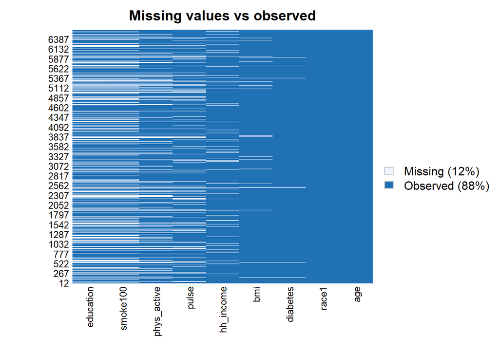

```r
NHANES_tailored |> Amelia::missmap(main = "Missing values vs observed")
```

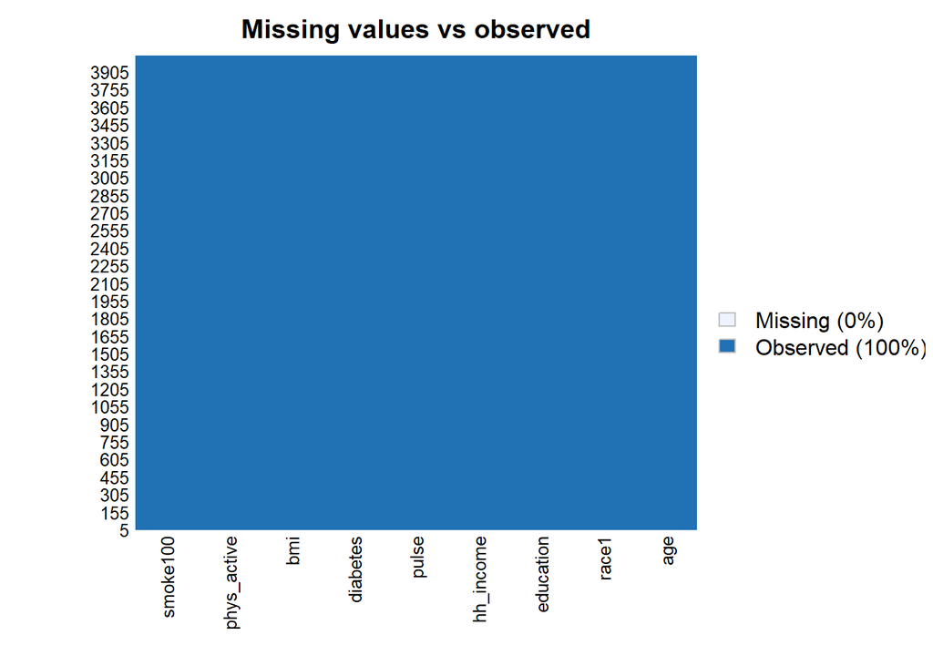

```r
NHANES_tailored = NHANES_tailored |> drop_na()

NHANES_tailored |> Amelia::missmap(main = "Missing values vs observed")
```

```r
#tidyverse way to create data partition
set.seed(123)

train.indices = NHANES_tailored |>
  pull(diabetes) |>
  createDataPartition(p = 0.7, list = FALSE)

train.data = NHANES_tailored |>
  slice(train.indices)

test.data = NHANES_tailored |>
  slice(-train.indices)

summary(NHANES_tailored$diabetes)
```

```
##   No  Yes
## 3562  478
```

```r
# Note that data are slightly unbalanced.
```

# 3. Model building

## classification tree

```r
set.seed(123)
#Creating 10-fold cross-validation and using down-sampling because of imbalance in data
control= trainControl(method="cv", number=10, sampling="down", classProbs = T)

# Up-sampling is preferred when the dataset is small, and data loss is a concern, while down-sampling might be more appropriate for large datasets where training time and resource utilization are significant considerations.


# classification tree

modelLookup("rpart")
```

```
##   model parameter                label forReg forClass probModel
## 1 rpart        cp Complexity Parameter   TRUE     TRUE      TRUE
```

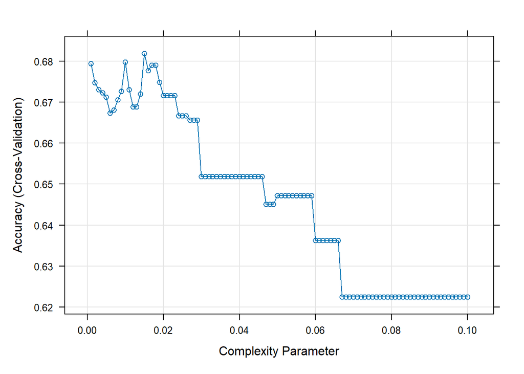

```r
#Specify tuneGrid so caret explores wider variety of cp-values
set.seed(123)

#Create different values of cp to try
cp.grid=expand.grid(cp=seq(0.001,0.1, by=0.001))
tree=train(
                     diabetes ~ .,
                     data=train.data,
                     method="rpart",
                     trControl=control,
                     tuneGrid=cp.grid,
                     preProcess=c("center", "scale")
                     )

plot(tree, uniform=TRUE)
```

```r
tree$bestTune
```

```
##       cp
## 15 0.015
```

```r
tree$results
```

```
##        cp  Accuracy     Kappa AccuracySD    KappaSD
## 1   0.001 0.6793960 0.1860360 0.02719124 0.04118558
## 2   0.002 0.6747635 0.1853100 0.04281398 0.04572766
## 3   0.003 0.6729967 0.1819731 0.03982714 0.04278820
## 4   0.004 0.6723000 0.1887908 0.03563237 0.03598823
## 5   0.005 0.6712424 0.1955107 0.03547253 0.03282907
## 6   0.006 0.6673567 0.2031245 0.03549025 0.03725830
## 7   0.007 0.6680609 0.2013645 0.03682914 0.04713440
## 8   0.008 0.6705432 0.2021728 0.03090022 0.04516174
## 9   0.009 0.6726734 0.2095178 0.04396298 0.04778860
## 10  0.010 0.6797880 0.2211364 0.05292402 0.04454600
## 11  0.011 0.6730742 0.2179533 0.05288914 0.04622700
## 12  0.012 0.6688439 0.2148097 0.05341186 0.04427196
## 13  0.013 0.6688439 0.2148097 0.05341186 0.04427196
## 14  0.014 0.6720129 0.2126418 0.05122334 0.04005831
```

[output cut: 86 more lines]

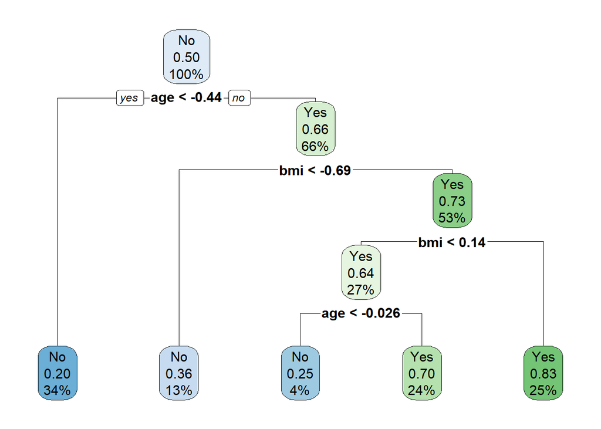

```r
#Plot new "best" tree
tree$finalModel |>
  rpart.plot()
```

```r
#Example variable importance in model
varImp(tree)
```

```
## rpart variable importance
##
##   only 20 most important variables shown (out of 26)
##
##                         Overall
## age                     100.000
## bmi                      65.948
## phys_activeYes           34.379
## educationCollege Grad    26.661
## hh_incomemore 99999      20.201
## race1White                7.320
## pulse                     2.347
## `educationHigh School`    0.000
## smoke100Yes               0.000
## race1Hispanic             0.000
## race1Other                0.000
## `hh_income20000-24999`    0.000
## `hh_income55000-64999`    0.000
## `hh_incomemore 99999`     0.000
## `educationCollege Grad`   0.000
## `hh_income 5000-9999`     0.000
## `hh_income65000-74999`    0.000
## `educationSome College`   0.000
## `hh_income10000-14999`    0.000
## `hh_income25000-34999`    0.000
```

## Support Vector Machine

```r
library(e1071)
modelLookup("svmLinear")
```

```
##       model parameter label forReg forClass probModel
## 1 svmLinear         C  Cost   TRUE     TRUE      TRUE
```

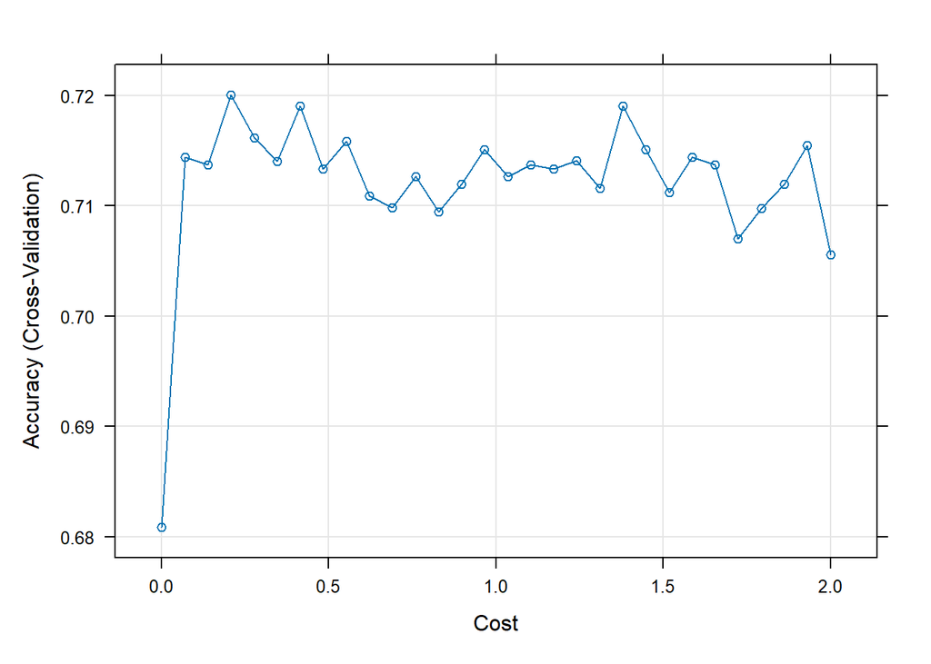

```r
set.seed(123)
#Incorporate different values for cost (C)
svm=train(
                    diabetes ~ .,
                    data=train.data,
                    method="svmLinear",
                    trControl=control,
                    preProcess=c("center", "scale"),
                    tuneGrid=expand.grid(C=seq(0.001,2, length=30))
                    )

#Visualize accuracy versus values of C
plot(svm)
```

```r
svm$bestTune
```

```
##           C
## 4 0.2077931
```

```r
#See information about final model
svm$finalModel
```

```
## Support Vector Machine object of class "ksvm"
##
## SV type: C-svc  (classification)
##  parameter : cost C = 0.207793103448276
##
## Linear (vanilla) kernel function.
##
## Number of Support Vectors : 408
##
## Objective Function Value : -81.1628
## Training error : 0.232836
## Probability model included.
```

## Logistic Regression

```r
set.seed(123)

logistic = train(diabetes ~ .,
                  data = train.data, method = "glm",
                  family = "binomial",
                  trControl = control,
                  preProcess=c("center", "scale"))
```

# 4. Model selection and evaluation

```r
#Obtain metrics of accuracy from training
confusionMatrix(tree)
```

```
## Cross-Validated (10 fold) Confusion Matrix
##
## (entries are percentual average cell counts across resamples)
##
##           Reference
## Prediction   No  Yes
##        No  59.3  3.0
##        Yes 28.8  8.9
##
##  Accuracy (average) : 0.6819
```

```r
confusionMatrix(svm)
```

```
## Cross-Validated (10 fold) Confusion Matrix
##
## (entries are percentual average cell counts across resamples)
##
##           Reference
## Prediction   No  Yes
##        No  62.8  2.6
##        Yes 25.4  9.2
##
##  Accuracy (average) : 0.72
```

```r
confusionMatrix(logistic)
```

```
## Cross-Validated (10 fold) Confusion Matrix
##
## (entries are percentual average cell counts across resamples)
##
##           Reference
## Prediction   No  Yes
##        No  62.9  2.8
##        Yes 25.2  9.0
##
##  Accuracy (average) : 0.7193
```

## Support Vector Machine

```r
#Create predictions in test set
pred.svm = svm |>
              predict(test.data)

eval.results=confusionMatrix(pred.svm, test.data$diabetes, positive = "Yes")
print(eval.results)
```

```
## Confusion Matrix and Statistics
##
##           Reference
## Prediction  No Yes
##        No  733  29
##        Yes 335 114
##
##                Accuracy : 0.6994
##                  95% CI : (0.6727, 0.7251)
##     No Information Rate : 0.8819
##     P-Value [Acc > NIR] : 1
##
##                   Kappa : 0.251
##
##  Mcnemar's Test P-Value : <2e-16
##
##             Sensitivity : 0.79720
##             Specificity : 0.68633
##          Pos Pred Value : 0.25390
##          Neg Pred Value : 0.96194
##              Prevalence : 0.11808
##          Detection Rate : 0.09414
##    Detection Prevalence : 0.37077
##       Balanced Accuracy : 0.74177
##
##        'Positive' Class : Yes
##
```

[figure not shown]

```r
#Create predictions as probabilities on test set
pred.svm.prob = svm |>
  predict(test.data, type = "prob")

#Another potential evaluation: Area under the Receiver Operating Curve (AUROC)
analysis = roc(response=test.data$diabetes, predictor=pred.svm.prob[,2])
plot(1-analysis$specificities,analysis$sensitivities,type="l",
ylab="Sensitivity",xlab="1-Specificity",col="red",lwd=2,
main = "ROC Curve for three models")
abline(a=0,b=1)
```

- The model appears to have a fair capacity to identify the positive class(sensitivity/recall=79.72%) but struggles with precision(precision=25.39%), indicating a high rate of false positives. This is also suggested by the low positive predictive value. The model is not outperforming a naive classifier that would predict the most frequent class for all cases, as evidenced by the comparison to the NIR and the associated p-value. The balanced accuracy is 74.18%, which is a better metric than accuracy for imbalanced datasets.

# 5. Ethical consideration of using race as a predictor

- Including race as a predictor in disease prediction models raises significant ethical considerations, reflecting broader societal issues around equity, discrimination, and the interpretation of genetic versus socio-environmental determinants of health. It may divert attention from underlying causes of health disparities, such as socio-economic status, physical activity and BMI which are more directly actionable.